# PML assignment

Lerh Shong

November 13, 2016

# Objective

The objective of this assignment is to predict the classe variable in this [dataset](http://groupware.les.inf.puc-rio.br/har).

# Preliminary steps

The following preprocessing steps were used:

1. Removal of missing values - There were 67 columns with missing values, and each of those columns have 19216 missing values. This is 98% of the dataset hence no imputation was done.
2. Removal of near-zero variance columns - Numeric columns that had close to zero variance was removed, with the default settings of the nearZeroVar function.
3. Removal of non-numeric columns - The non-numeric columns were identifiers with the exception of actual time. As raw time was provided, actual time was removed as well.
4. Scaling - Data was scaled for training.

# Training the model

The two methods used were xgbLinear and xgbTree, with 3-fold cross validation. These methods had an accuracy of 0.99. Either would be fine, though xgbLinear was chosen as it did slightly better in resampling. The expected out of sample error would be minimal based on the resampling plot.

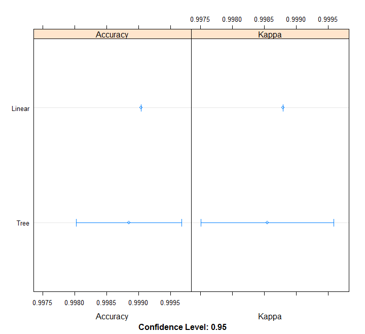